# Lab02_LindsayDahlen

Lindsay Dahlen

September 10, 2017

### Learning Objectives

> - Work with vectors of different data types
> - Understand the concept of *atomic* structures
> - Learn how to subset and slice R vectors
> - Understand the concept of *vectorization*
> - Understand *recycling* rules in R

## Getting the Data File

In this lab, you are going to work with a handful of variables about NBA players from the regular season 2016-2017:

- `player`: name of the player.
- `team`: team name abbreviation.
- `position`: player position.
- `salary`: salary (in dollars).
- `points`: total scored points.
- `points1`: number of free throws, worth 1 point each.
- `points2`: number of 2-point field goals, worth 2 points each.
- `points3`: number of 3-point field goals, worth 3 points each.

The data is in the file `nba2017-salary-points.RData`, located in the `data/` folder of this github repository. The original source of the data is the website [www.basketball-reference.com](http://www.basketball-reference.com/)

Open a new session in Rstudio, and make sure you have a clean workspace by typing this command on the console:

```r
# remove existing objects
rm(list = ls())
```

You can download the `.RData` file to your working directory, and then `load()` it with the code below. Do NOT include these commands in your source Rmd file; simply type them directly on the console:

```r
# download RData file into your working directory
rdata <- "https://github.com/ucb-stat133/stat133-fall-2017/raw/master/data/nba2017-salary-points.RData"
download.file(url = rdata, destfile = 'nba2017-salary-points.RData')
```

### What’s happening in the code above?

The function `download.file()` allows you to download any type of file from the Web. In this case you are downloading the file called `nba2017-salary-points.RData` which is located in the github repository of the course. This file is a binary file. To be more precise, the file extension `.RData` is the default extension used by R for its binary native format.

Where does the file get downloaded? Bby default, the file `nba2017-salary-points.RData` gets downloaded to your **working directory**. If you are curious about what is the current directory to which R is paying attention to, simply type the function `getwd()`—which stands for *get the working directory*.

If you want to specify a specific location for the downloaded file, then modify the `destfile` parameter. For instance, if you are using Mac, and you want the file to be downloaded to your desktop, you can use:

```r
# download RData file to your Desktop (assuming you use Mac)
rdata <- "https://github.com/ucb-stat133/stat133-fall-2017/raw/master/data/nba2017-salary-points.RData"
download.file(url = rdata, destfile = '~/Desktop/nba2017-salary-points.RData')
```

### Loading the data file

To load or import the contents of the binary file into your R session you use `load()`. This function allows you to import R binary files. This time, include the code below in your `Rmd` file:

```r
# load data in your R session

load('~/nba2017-salary-points.RData')
#head(player)
```

Note: the code above will only work as long as your `Rmd` file lives in the same directory of the `.RData` file. So far I’m assuming that you have both files in the working directory. If you run into problems, ask the GSI or any of the lab assistants.

Once you imported (or loaded) the data, use the function `ls()` which allows you to **list** all the available R objects:

```r
# list the available objects with ls()
ls()
```

Check that the following objects are available in your session:

- `player`
- `team`
- `position`
- `salary`
- `points`

### About `.RData` files

Most of the data sets you are going to be working with in real life are going to be stored in some sort of text file. So you probably won’t be handling many R binary files (i.e. `.RData` files). However, R binary files are an interesting option for saving intermediate results, and/or for saving R objects (as R objects).

### Inspecting the data objects

Once you have some data objects to work with, the first step is to inspect some of their characteristics. R has various functions that allow you to examine objects:

- `typeof()` type of storage of any object
- `class()` gives you the class of the object
- `str()` displays the structure of an object in a compact way
- `mode()` gives the data type (as used in R)
- `object.size()` gives an estimate of the memory space used by an object
- `length()` gives the length (i.e. number of elements)
- `head()` take a peek at the first elements
- `tail()` take a peek at the last elements
- `summary()` shows a summary of a given object

Your turn. Find out what is the class of each of the objects `player`, `team`, etc:

```r
# your code here
class(player)
```

```
## [1] "character"
```

```r
class(team)
```

```
## [1] "factor"
```

```r
class(position)
```

```
## [1] "character"
```

```r
class(salary)
```

```
## [1] "numeric"
```

```r
class(points)
```

```
## [1] "integer"
```

Now use `length()`, `head()`, `tail()`, and `summary()` to start exploring the content of the objects:

```r
# your code here

length(player)
```

```
## [1] 441
```

```r
length(team)
```

```
## [1] 441
```

```r
length(position)
```

```
## [1] 441
```

```r
length(salary)
```

```
## [1] 441
```

```r
length(points)
```

```
## [1] 441
```

```r
head(player)
```

```
## [1] "Al Horford"        "Amir Johnson"      "Avery Bradley"
## [4] "Demetrius Jackson" "Gerald Green"      "Isaiah Thomas"
```

```r
head(team)
```

```
## [1] BOS BOS BOS BOS BOS BOS
## 30 Levels: ATL BOS BRK CHI CHO CLE DAL DEN DET GSW HOU IND LAC LAL ... WAS
```

```r
head(position)
```

```
## [1] "C"  "PF" "SG" "PG" "SF" "PG"
```

```r
head(salary)
```

```
## [1] 26540100 12000000  8269663  1450000  1410598  6587132
```

```r
head(points)
```

```
## [1]  952  520  894   10  262 2199
```

```r
tail(player)
```

```
## [1] "Leandro Barbosa" "Marquese Chriss" "Ronnie Price"    "T.J. Warren"
## [5] "Tyler Ulis"      "Tyson Chandler"
```

```r
tail(team)
```

```
## [1] PHO PHO PHO PHO PHO PHO
## 30 Levels: ATL BOS BRK CHI CHO CLE DAL DEN DET GSW HOU IND LAC LAL ... WAS
```

```r
tail(position)
```

```
## [1] "SG" "PF" "PG" "SF" "PG" "C"
```

```r
tail(salary)
```

```
## [1]  4000000  2941440   282595  2128920   918369 12415000
```

```r
tail(points)
```

```
## [1] 419 753  14 951 444 397
```

```r
summary(player)
```

```
##    Length     Class      Mode
##       441 character character
```

```r
summary(team)
```

```
## ATL BOS BRK CHI CHO CLE DAL DEN DET GSW HOU IND LAC LAL MEM MIA MIL MIN
##  14  15  15  15  15  15  15  15  15  15  14  14  15  15  15  14  14  14
## NOP NYK OKC ORL PHI PHO POR SAC SAS TOR UTA WAS
##  14  15  15  15  15  15  14  15  15  15  15  14
```

```r
summary(position)
```

```
##    Length     Class      Mode
##       441 character character
```

```r
summary(salary)
```

```
##     Min.  1st Qu.   Median     Mean  3rd Qu.     Max.
##     5145  1286160  3500000  6187014  9250000 30963450
```

```r
summary(points)
```

```
##    Min. 1st Qu.  Median    Mean 3rd Qu.    Max.
##     0.0   156.0   432.0   546.6   780.0  2558.0
```

Do all the objects have the same length? #Yes.

## Vectors in R

Vectors are the most basic type of data structures in R. Learning how to manipulate data structures in R requires you to start learning how to manipulate vectors.

How do you know if any of the loaded objects is a vector? Using `class()` does not explicitly tell you whether an R object is a vector or not. A more explicit way to check if `player` or `position` are vectors is with the function `is.vector()`.

```r
# check whether the loaded objects are vectors
is.vector(player)
```

```
## [1] TRUE
```

Remember that R vectors are **atomic structures**, which is just the fancy name to indicate that all the elements of a vector must be of the same type, either all numbers, all characters, or all logical values. To test if an object is *atomic*, i.e. has all its elements of the same type, use `is.atomic()`

```r
# check whether the loaded objects are atomic objects
is.atomic(position)
```

```
## [1] TRUE
```

How do you know that a given vector is of a certain data type? One function to answer this question is `typeof()`

```r
typeof(player)
```

```
## [1] "character"
```

```r
typeof(position)
```

```
## [1] "character"
```

```r
typeof(points)
```

```
## [1] "integer"
```

You should know that among the R community, most useRs don’t talk about *types*. Instead, because of historical reasons related to the S language, we talk about *modes*.

## Manipulating Vectors: Subsetting

Subsetting refers to extracting elements of a vector (or another R object). To do so, you use what is known as **bracket notation**. This implies using (square) brackets `[ ]` to get access to the elements of a vector, for instance:

```r
# first element of 'player'
player[1]

# first five elements of 'player'
player[1:5]
```

What type of things can you specify inside the brackets? Basically:

- numeric vectors
- logical vectors (the length of the logical vector must match the length of the vector to be subset)
- character vectors (if the elements have names)

### Subsetting with Numeric Indices

Here are some subsetting examples using a numeric vector inside the brackets:

```r
# fifth element of 'player'
player[5]

# numeric range
player[2:8]

# numeric vector
player[c(1, 3, 5, 7)]

# different order
player[c(20, 9, 10, 50)]

# third element (four times)
player[rep(3, 4)]
```

Subset the first four players:

```r
four <- player[1:4]
four
```

```
## [1] "Al Horford"        "Amir Johnson"      "Avery Bradley"
## [4] "Demetrius Jackson"
```

Now try these. What happens if you specify:

- an index of zero: `four[0]`?
- a negative index: `four[-1]`?
- various negative indices: `four[-c(1,2,3)]`?
- an index greater than the length of the vector: `four[5]`?
- repeated indices: `four[c(1,2,2,3,3,3)]`?

```r
four[0]
```

```
## character(0)
```

```r
four[-1]
```

```
## [1] "Amir Johnson"      "Avery Bradley"     "Demetrius Jackson"
```

```r
four[-c(1,2,3)]
```

```
## [1] "Demetrius Jackson"
```

```r
four[5]
```

```
## [1] NA
```

```r
four[c(1,2,2,3,3,3)]
```

```
## [1] "Al Horford"    "Amir Johnson"  "Amir Johnson"  "Avery Bradley"
## [5] "Avery Bradley" "Avery Bradley"
```

Often, you will need to generate vectors of numeric sequences, like the first five elements `1:5`, or from the first till the last element `1:length(player)`. R provides the colon operator `:`, and the functions `seq()`, and `rep()` to create various types of sequences.

Figure out how to use `seq()`, `rep()` to extract:

- all the even elements in `player`
- all the odd elements in `salary`
- all multiples of 5 (e.g. 5, 10, 15, etc) of `team`
- elements in positions 10, 20, 30, 40, etc of `points`
- all the even elements in `team` but this time in reverse order

```r
player[seq(1,length(player),2)]
```

```
##   [1] "Al Horford"               "Avery Bradley"
##   [3] "Gerald Green"             "Jae Crowder"
##   [5] "Jaylen Brown"             "Jordan Mickey"
##   [7] "Marcus Smart"             "Tyler Zeller"
##   [9] "Dahntay Jones"            "Derrick Williams"
##  [11] "Iman Shumpert"            "James Jones"
##  [13] "Kevin Love"               "Kyrie Irving"
##  [15] "Richard Jefferson"        "Bruno Caboclo"
##  [17] "Delon Wright"             "DeMarre Carroll"
##  [19] "Jakob Poeltl"             "Kyle Lowry"
##  [21] "Norman Powell"            "Pascal Siakam"
##  [23] "Serge Ibaka"              "Bradley Beal"
##  [25] "Chris McCullough"         "Ian Mahinmi"
##  [27] "John Wall"                "Markieff Morris"
##  [29] "Sheldon McClellan"        "Trey Burke"
```

[output cut: 96 more lines]

```r
salary[seq(2,length(player),2)]
```

```
##   [1] 12000000  1450000  6587132  1825200  5000000  3094014  1906440
##   [8]  7806971   259626     5145 12800000   543471  5239437 30963450
##  [15] 15330435  7330000 26540100   543471 14382022  1921320  5300000
##  [22]  6050000  3730653  1200000   543471  5000000 12000000  5893981
##  [29]  2870813  1499760 23180275   392478  4000000  4837500 20072033
##  [36]  3850000  2995421  5374320 12517606   925000  1403611  1811040
##  [43]  2568600  2700000  4583450  8800000  1800000  4000000  2463840
##  [50]  1052342  3488000  2112480  2092200  1015696 17552209  3183526
##  [57]   750000 13219250 15890000  4000000   874636  1227000   543471
##  [64]  4000000  1015696  6500000  7000000  1704120 10991957  4625000
##  [71]  2255644  2969880  1050961   874636  2730000   161483  6333333
##  [78] 13000000 20869566   543471   143860 21323250  1015696  3900000
##  [85]   543471  2898000  1410598  4351320  5000000   980431 17000000
##  [92]  6540000  3909840    31969 10000000  2318280  4788840  4826160
##  [99]  2993040  1015696    89513  8550000  6088993 21165675  1074145
```

[output cut: 17 more lines]

```r
team[seq(5,length(player),5)]
```

```
##  [1] BOS BOS BOS CLE CLE CLE TOR TOR TOR WAS WAS ATL ATL ATL MIL MIL MIL
## [18] IND IND IND CHI CHI CHI MIA MIA MIA DET DET DET CHO CHO CHO NYK NYK
## [35] NYK ORL ORL ORL PHI PHI PHI BRK BRK BRK GSW GSW GSW SAS SAS SAS HOU
## [52] HOU LAC LAC LAC UTA UTA UTA OKC OKC OKC MEM MEM MEM POR POR POR DEN
## [69] DEN DEN NOP NOP NOP DAL DAL DAL SAC SAC SAC MIN MIN MIN LAL LAL LAL
## [86] PHO PHO PHO
## 30 Levels: ATL BOS BRK CHI CHO CLE DAL DEN DET GSW HOU IND LAC LAL ... WAS
```

```r
points[seq(10,length(player),10)]
```

```
##  [1]  299    6  630  253   24  101 1246  767  815   59 1816  975  374 1105
## [15]  874   57   40   82  299  864  543  709 1742  130  638  639 1104  283
## [29]  100  421  425  551  586  262 1221  150  437  898  470  197  209  425
## [43]  168  444
```

```r
rev(player[seq(1,length(player),2)])
```

```
##   [1] "Tyson Chandler"           "T.J. Warren"
##   [3] "Marquese Chriss"          "Jared Dudley"
##   [5] "Elijah Millsap"           "Devin Booker"
##   [7] "Brandon Knight"           "Alan Williams"
##   [9] "Timofey Mozgov"           "Tarik Black"
##  [11] "Metta World Peace"        "Larry Nance Jr."
##  [13] "Jordan Clarkson"          "David Nwaba"
##  [15] "Corey Brewer"             "Zach LaVine"
##  [17] "Shabazz Muhammad"         "Omri Casspi"
##  [19] "Kris Dunn"                "Jordan Hill"
##  [21] "Cole Aldrich"             "Andrew Wiggins"
##  [23] "Willie Cauley-Stein"      "Ty Lawson"
##  [25] "Rudy Gay"                 "Langston Galloway"
##  [27] "Georgios Papagiannis"     "Darren Collison"
##  [29] "Ben McLemore"             "Anthony Tolliver"
```

[output cut: 96 more lines]

### Subsetting with Logical Indices

Logical subsetting involves using a logical vector inside the brackets. Learning about *logical subsetting* is a fundamental survival skill. This kind of subsetting is **very powerful** because it allows you to extract elements based on some logical condition.

Here’s a toy example of logical subsetting:

```r
# dummy vector
a <- c(5, 6, 7, 8)

# logical subsetting
a[c(TRUE, FALSE, TRUE, FALSE)]
```

```
## [1] 5 7
```

Logical subsetting occurs when the vector of indices that you pass inside the brackets is a logical vector.

To do logical subsetting, the vector that you put inside the brackets, should match the length of the manipulated vector. If you pass a shorter vector inside brackets, R will apply its recycling rules.

Notice that the elements of the vector that are subset are those which match the logical value `TRUE`.

```r
# your turn
four[c(TRUE, TRUE, TRUE, TRUE)]
four[c(TRUE, TRUE, FALSE, FALSE)]
four[c(FALSE, FALSE, TRUE, TRUE)]
four[c(TRUE, FALSE, TRUE, FALSE)]
four[c(FALSE, FALSE, FALSE, FALSE)]

# recycling
four[TRUE]
four[c(TRUE, FALSE)]
```

When subsetting a vector logically, most of the times you won’t really be providing an explicit vector of `TRUE`’s and `FALSE`s. Just imagine having a vector of 100 or 1000 or 1000000 elements, and trying to do logical subsetting by manually creating a logical vector of the same length. That would be very boring. Instead, you will be providing a logical condition or a comparison operation that returns a logical vector.

A **comparison operation** occurs when you use comparison operators such as:

- `>` greater than
- `>=` greater than or equal
- `<` less than
- `<=` less than or equal
- `==` equal
- `!=` different

```r
# elements greater than 6
a > 6
```

```
## [1] FALSE FALSE  TRUE  TRUE
```

```r
# elements different from 6
a != 6
```

```
## [1]  TRUE FALSE  TRUE  TRUE
```

Notice that a comparison operation always returns a logical vector. Here’s how you actually extract the values of a vector based on logical indexing:

```r
points_four <- points[1:4]

# elements greater than 100
points_four[points_four > 100]
```

```
## [1] 952 520 894
```

```r
# elements less than 100
points_four[points_four < 100]
```

```
## [1] 10
```

```r
# elements less than or equal to 10
points_four[points_four <= 10]
```

```
## [1] 10
```

```r
# elements different from 10
points_four[points_four != 10]
```

```
## [1] 952 520 894
```

In addition to using comparison operators, you can also use **logical operators** to produce a logical vector. The most common type of logical operators are:

- `&` AND
- `|` OR
- `!` negation

Run the following commands to see what R does:

```r
# AND
TRUE & TRUE
TRUE & FALSE
FALSE & FALSE

# OR
TRUE | TRUE
TRUE | FALSE
FALSE | FALSE

# NOT
!TRUE
!FALSE
```

Logical operators allow you to combine several comparisons:

```r
# players of Golden State (GSW)
player[team == 'GSW']

# name of players with salaries greater than 20 million dollars
player[salary > 20000000]

# name of players with scored points between 1000 and 1200 (exclusive)
player[points > 1000 & points < 1200]
```

### Your turn

Write commands, using bracket notation, to answer the following questions (you may need to use `min()`, `max()`, `which()`, `which.min()`, `which.max()`):

```r
# players in position Center, of Warriors (GSW)
player[team == 'GSW' & position == "C"]
```

```
## [1] "Damian Jones"  "David West"    "JaVale McGee"  "Kevon Looney"
## [5] "Zaza Pachulia"
```

```r
# players of both GSW (warriors) and LAL (lakers)
player[team == 'GSW' & position == 'LAL']
```

```
## character(0)
```

```r
# players in positions Shooting Guard and Point Guards, of Lakers (LAL)
player[(position == "SG" | position == "PG") & team == "LAL"]
```

```
## [1] "D'Angelo Russell" "David Nwaba"      "Jordan Clarkson"
## [4] "Nick Young"       "Tyler Ennis"
```

```r
# subset Small Forwards of GSW and LAL
player[position == "SF" & (team == "GSW" | team == "LAL")]
```

```
## [1] "Andre Iguodala"    "Kevin Durant"      "Matt Barnes"
## [4] "Brandon Ingram"    "Corey Brewer"      "Luol Deng"
## [7] "Metta World Peace"
```

```r
# name of the player with largest salary
player[salary == max(salary)]
```

```
## [1] "LeBron James"
```

```r
# name of the player with smallest salary
player[salary == min(salary)]
```

```
## [1] "Edy Tavares"
```

```r
# name of the player with largest number of points
player[points == max(points)]
```

```
## [1] "Russell Westbrook"
```

```r
# salary of the player with largest number of points
salary[points == max(points)]
```

```
## [1] 26540100
```

```r
# largest salary of all Centers
max(salary[position == 'C'])
```

```
## [1] 26540100
```

```r
# team of the player with the largest number of points
team[points == max(points)]
```

```
## [1] OKC
## 30 Levels: ATL BOS BRK CHI CHO CLE DAL DEN DET GSW HOU IND LAC LAL ... WAS
```

```r
# name of the player with the largest number of 3-pointers
player[points3 == max(points3)]
```

```
## [1] "Stephen Curry"
```

### Subsetting with Character Vectors

A third type of subsetting involves passing a character vector inside brackets. When you do this, the characters are supposed to be names of the manipulated vector.

None of the vectors `player`, `position`, `points`, and `salary` have names. You can confirm that with the `names()` function applied on any of the vectors:

```r
names(player)
```

Create a vector `warriors_player` by selecting the players of `team == 'GSW'`; then create a vector `warriors_salary` with their salaries, and another vector `warriors_points` with their `points`. Assign `warriors_player` as the names of `warriors_salary`.

```r
# create warriors_player


# create warriors_salary


# create warriors_points
```

```r
warriors_player <- player[team == 'GSW']

warriors_salary <- salary[team == 'GSW']

warriors_points <- points[team == 'GSW']
```

You should have a vector `warriors_salary` with named elements. Now you can use character subsetting:

```r
warriors_salary["Andre Iguodala"]

warriors_salary[c("Stephen Curry", "Kevin Durant")]
```

### Some plotting

Use the function `plot()` to make a scatterplot of `points` and `salary`

```r
plot(points, salary)
```

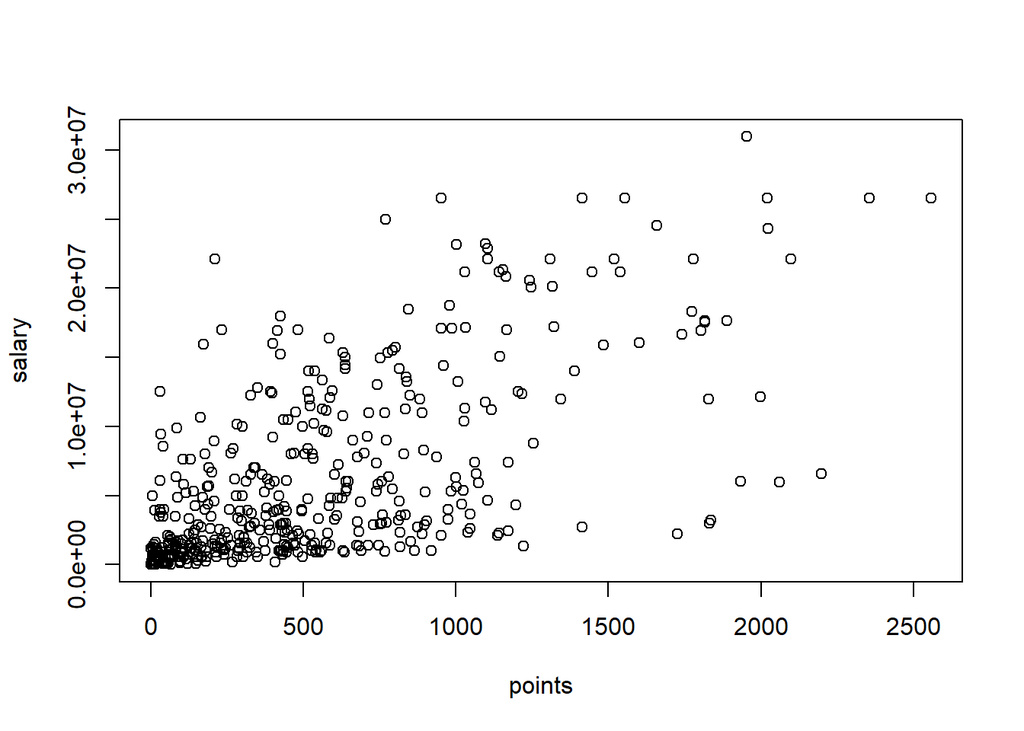

```r
plot(points, salary)
```

Keep in mind that `plot()` is a generic function. This means that the behavior of `plot()` depends on the type of input. When you pass two numeric vectors, `plot()` will attempt to create a scatter plot.

Looking at the generated plot, can you see any issues?

To get a better display of the scatterplot, let’s create two vectors `log_points` and `log_salary` by transforming `points` and `salary` with the logarithm function `log()`

```r
log_points <- log(points)
log_salary <- log(salary)
```

Make another scatterplot but now use the log-transformed vectors:

```r
plot(log_points, log_salary)
```

To add the names of the players in the plot, you can use the low-level graphing function `text()`:

```r
plot(log_points, log_salary)
text(log_points, log_salary, labels = player)
```

Now we have another problem. The labels in the plot are very messy. A quick and dirty fix is to use `abbreviate()` to shorten the displayed names:

```r
plot(log_points, log_salary)

text(log_points, log_salary, labels = abbreviate(player))
```

**Your Turn**: create a scatterplot of points and salary for the Warriors (GSW), displaying the names of the players. Generate two scatterplots, one with raw values (original scale, and another plot with log-transformations).

```r
plot(warriors_points,warriors_salary)
text(warriors_points, warriors_salary, labels = abbreviate(player))

log_warriorspoints <- log(warriors_points)
log_warriorssalary <- log(warriors_salary)
plot(log_warriorspoints,log_warriorssalary)
text(log_warriorspoints, log_warriorssalary, labels = abbreviate(player))
```

## Vectorization

When you create the vectors `log_points <- log(points)` and `log_salary <- log(salary)`, what you’re doing is applying a function to a vector, which in turn acts on all elements of the vector.

This is called **Vectorization** in R parlance. Most functions that operate with vectors in R are **vectorized** functions. This means that an action is applied to all elements of the vector without the need to explicitly type commands to traverse all the elements.

In many other programming languages, you would have to use a set of commands to loop over each element of a vector (or list of numbers) to transform them. But not in R.

Another example of vectorization would be the calculation of the square root of all the elements in `points` and `salary`:

```r
sqrt(points)
sqrt(salary)
```

```r
sqrt(points)
```

```
##   [1] 30.854497 22.803509 29.899833  3.162278 16.186414 46.893496 31.606961
##   [8]  8.246211 22.693611 17.291616  6.164414 26.038433 28.896367 20.248457
##  [15] 13.341664 26.000000  3.000000 13.379088 12.489996  2.449490 23.811762
##  [22] 18.734994 11.489125 12.884099 33.793490 19.313208 42.614552 44.204072
##  [29] 21.166010 25.099801  3.741657 27.202941 12.247449 44.944410 25.258662
##  [36] 10.344080 12.845233 30.967725 36.660606 15.905974 25.219040 11.789826
##  [43] 15.132746 21.095023 18.083141 18.165902 42.178193  9.000000  1.000000
##  [50]  4.898979 13.152946 20.493902 42.485292 29.715316 32.603681 32.787193
##  [57]  9.486833 12.409674 16.881943 10.049876 37.603191 31.654384 16.431677
##  [64]  7.810250 28.301943 16.031220 19.773720 13.000000 20.856654 35.298725
##  [71]  5.000000 21.071308 33.808283 42.801869 30.838288 32.015621 17.521415
##  [78] 19.798990 20.639767 27.694765 24.020824 22.978251 21.236761 11.916375
##  [85]  9.110434 15.033296 26.134269 17.944358 23.130067 28.548205  4.582576
##  [92] 35.411862  8.246211 15.231546  6.557439 13.304135 25.099801 34.249088
##  [99] 42.130749  7.681146 28.530685  6.403124 20.904545  7.348469 17.776389
```

[output cut: 48 more lines]

```r
sqrt(salary)
```

```
##   [1] 5151.70845 3464.10162 2875.70218 1204.15946 1187.68599 2566.54086
##   [7] 2507.27103 1350.99963 2177.84297 2236.06798 1106.18850 1758.98095
##  [13] 1891.79280 1380.73893 2828.42712 2794.09574  135.11107  509.53508
##  [19]  517.71517   71.72866 3114.48230 3577.70876 1245.65605  737.20486
##  [25] 4600.61681 2288.98165 4199.76940 5564.48111 1581.13883 3915.40994
##  [31] 1260.80926 2707.39727 1255.89809 5151.70845 3768.28874  737.20486
##  [37] 1644.37222 3792.36364 3464.10162 1386.11688  935.21976 2302.17289
##  [43] 1093.63614 2459.67478 3500.00000 1931.48984 4702.84488 1095.44512
##  [49] 1091.54936  737.20486 3993.01315 2236.06798 4117.99709 3464.10162
##  [55] 2720.29410 2427.75225  737.20486 1694.34737 1840.27118 1224.64689
##  [61] 1645.77702 4814.58981 2898.27535  626.48065 3966.14901 2000.00000
##  [67] 1581.13883 2199.43174 1007.81744 4480.18225  646.70550 1962.14169
##  [73] 1510.49826 1730.72846 4135.21463 2318.25797 1245.65605 3538.02289
##  [79] 3898.71774  961.76920 3099.59675 1184.74090 3240.37035 1345.74886
##  [85] 2519.67438 1602.68525 1538.93697 1643.16767 3198.46510 2140.89934
```

[output cut: 59 more lines]

### Why should you care about vectorization?

If you are new to programming, learning about R’s vectorization will be very natural (you won’t stop to think about it too much). If you have some previous programming experience in other languages (e.g. C, python, perl), you know that vectorization does not tend to be a native thing.

Vectorization is essential in R. It saves you from typing many lines of code, and you will exploit vectorization with other useful functions known as the *apply* family functions (we’ll talk about them later in the course).

## Recycling

Closely related with the concept of *vectorization* we have the notion of **Recycling**. To explain *recycling* let’s see an example.

`salary` is given in dollars, but what if you need to obtain the salaries in millions of dollars?. Create a new vector `salary_millions` with the converted values in millions of dollars.

```r
salary_millions <- salary*(1/1000000)
salary_millions
```

```
##   [1] 26.540100 12.000000  8.269663  1.450000  1.410598  6.587132  6.286408
##   [8]  1.825200  4.743000  5.000000  1.223653  3.094014  3.578880  1.906440
##  [15]  8.000000  7.806971  0.018255  0.259626  0.268029  0.005145  9.700000
##  [22] 12.800000  1.551659  0.543471 21.165675  5.239437 17.638063 30.963450
##  [29]  2.500000 15.330435  1.589640  7.330000  1.577280 26.540100 14.200000
##  [36]  0.543471  2.703960 14.382022 12.000000  1.921320  0.874636  5.300000
##  [43]  1.196040  6.050000 12.250000  3.730653 22.116750  1.200000  1.191480
##  [50]  0.543471 15.944154  5.000000 16.957900 12.000000  7.400000  5.893981
##  [57]  0.543471  2.870813  3.386598  1.499760  2.708582 23.180275  8.400000
##  [64]  0.392478 15.730338  4.000000  2.500000  4.837500  1.015696 20.072033
##  [71]  0.418228  3.850000  2.281605  2.995421 17.100000  5.374320  1.551659
##  [78] 12.517606 15.200000  0.925000  9.607500  1.403611 10.500000  1.811040
##  [85]  6.348759  2.568600  2.368327  2.700000 10.230179  4.583450  0.650000
##  [92]  8.800000  1.052342  1.800000  4.000000  4.000000 10.770000  2.463840
##  [99] 18.314532  1.052342 14.153652  3.488000  1.453680  2.112480  0.874636
```

[output cut: 48 more lines]

```r
# ignore
```

What you just did (assuming that you did things correctly) is called **Recycling**. To understand this concept, you need to remember that R does not have a data structure for scalars (single numbers). Scalars are in reality vectors of length 1.

### Another recycling example

Here’s another example of recycling. Heights of elements in an odd number position will be transformed to cms; heights of elements in an even number position will be transformed to meters:

```r
units <- c(2.54, 0.0254)
mix_height <- height * units
```

The elements of `units` are recycled and repeated as many times as elements in `height`. The previous command is equivalent to this:

```r
new_units <- rep(c(2.54, 0.0254), length.out = length(height))
height * new_units
```

## Factors

As mentioned before, vectors are the most essential type of data structure in R. They are *atomic* structures (can contain only one type of data): integers, real numbers, logical values, characters, complex numbers.

Related to vectors, there is another important data structure in R called **factor**. Factors are data structures exclusively designed to handle categorical data.

The object `team` is an R factor. You can confirm this by using `is.factor()` or `class()`

```r
is.factor(team)
```

```
## [1] TRUE
```

```r
class(team)
```

```
## [1] "factor"
```

### Creating Factors

Use `factor()` to create an object `position_fac` by converting `position` into a factor:

```r
position_fac <- factor(position)
```

If you have a factor, you can invoke `table()` to get a table with the frequencies (i.e. counts) of the factor categories or *levels*:

```r
table(position_fac)
```

```
## position_fac
##  C PF PG SF SG
## 89 89 85 83 95
```

### Manipulating Factors

Because factors are internally stored as integers, you can manipulate factors as any other vector:

```r
position_fac[1:5]
```

```
## [1] C  PF SG PG SF
## Levels: C PF PG SF SG
```

Practice manipulating `position_fac` to get:

```r
# positions of Warriors
position_fac[team == 'GSW']
```

```
##  [1] SF C  C  PF SG PF C  SF C  SG SF SG PG PG C
## Levels: C PF PG SF SG
```

```r
# positions of players with salaries > 15 millions
position_fac[salary > 15000000]
```

```
##  [1] C  PF PG SF C  SG SG C  PG C  SF PF C  SF SF SG SF PG C  C  PF SG SF
## [24] PG C  C  SG C  PF SF SG SF PF C  PG PF PF PG C  SF C  PG SF C  PG SG
## [47] PG SF SF C  C  PF PF SG SF C
## Levels: C PF PG SF SG
```

```r
# frequencies (counts) of positions with salaries > 15 millions
table(position_fac[salary > 15000000])
```

```
##
##  C PF PG SF SG
## 17  9  9 13  8
```

```r
# relative frequencies (proportions) of 'SG' (Shooting Guards) in each team
prop.table(table(team[position_fac == 'SG']))
```

```
##
##        ATL        BOS        BRK        CHI        CHO        CLE
## 0.01052632 0.03157895 0.04210526 0.04210526 0.04210526 0.03157895
##        DAL        DEN        DET        GSW        HOU        IND
## 0.02105263 0.04210526 0.03157895 0.03157895 0.03157895 0.02105263
##        LAC        LAL        MEM        MIA        MIL        MIN
## 0.03157895 0.03157895 0.03157895 0.04210526 0.04210526 0.02105263
##        NOP        NYK        OKC        ORL        PHI        PHO
## 0.02105263 0.04210526 0.02105263 0.04210526 0.02105263 0.04210526
##        POR        SAC        SAS        TOR        UTA        WAS
## 0.04210526 0.05263158 0.05263158 0.03157895 0.02105263 0.03157895
```

```r
position_fac[team == 'GSW']
```

```
##  [1] SF C  C  PF SG PF C  SF C  SG SF SG PG PG C
## Levels: C PF PG SF SG
```

### More Plots

Let’s go back to the scatterplot of `points` and `salary`

```r
plot(points, salary)
```

But now use your factor `position_fac` to add some color to the dots in the scatterplot. Pass the factor to the `col =` parameter inside `plot()`

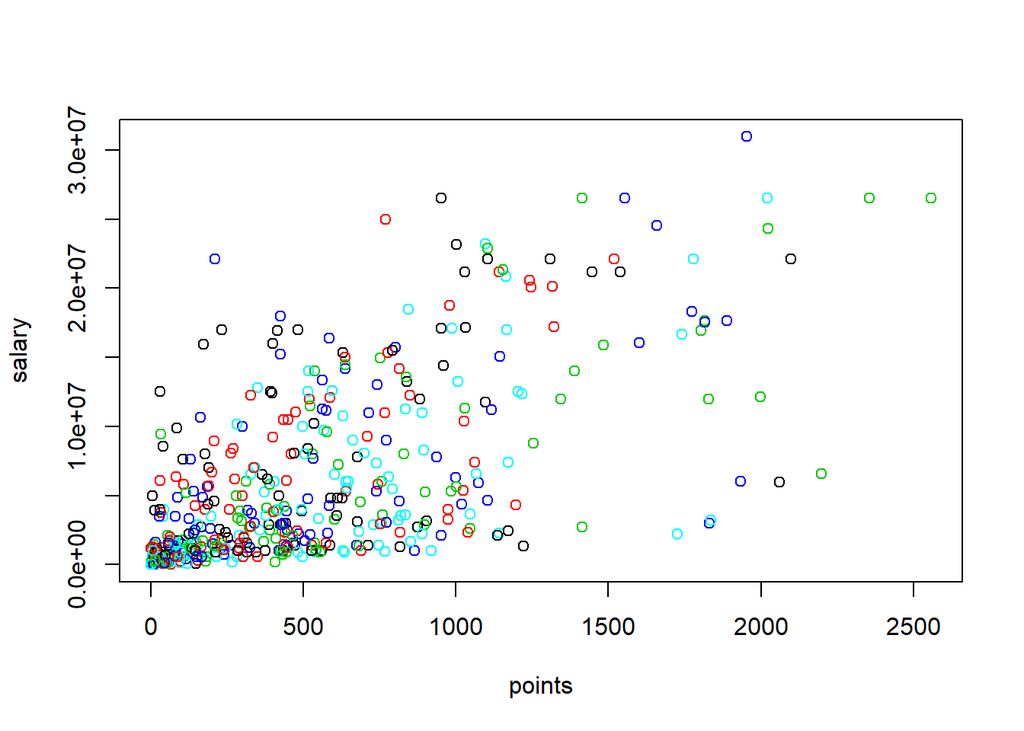

```r
plot(points,salary, col = position_fac)
```

Experiment with other `plot()` arguments like the *point character* `pch =`, the *size of dots* with the parameter `cex =`, the axes labels `xlab` and `ylab` and so on.